[figure not shown]

# YouTube Thumbnail A/B Testing

[figure not shown]

## 📌 Introduction

In the digital age, content creators on YouTube constantly compete for viewer attention. One of the most powerful yet often overlooked factors in a video's success is its **thumbnail** — the first visual impression a potential viewer gets before deciding to click.

This project simulates a real-world **A/B test** conducted by a YouTuber who wants to find out whether a redesigned thumbnail performs better than the original. By running a controlled experiment over 30 days, we can use data and statistics to make a confident, evidence-based decision — rather than relying on guesswork.

## 🛠️ Tools Used

- Python
- Pandas
- NumPy
- Matplotlib
- Seaborn
- SciPy
- Jupyter Notebook

## 📌 Import Libraries and Dataset

```python
import pandas as pd
import matplotlib.pyplot as plt
import seaborn as sns

import warnings
warnings.filterwarnings('ignore')

from statsmodels.stats.proportion import proportions_ztest
from scipy.stats import ttest_ind
```

```python
df = pd.read_csv("/kaggle/input/datasets/akisavujel/thumbnail/Thumbnail_A_B_testing.csv")
```

## 🧐 Understand the Dataset (EDA)

```python
print("----- First 5 rows -----")
print(df.head())
```

```
----- First 5 rows -----
   Day Variant  Impressions  Clicks  CTR  Avg_watch_time
0    1       A         2175     870  0.4             2.0
1    2       A         3220     966  0.3             2.3
2    3       A         2537    1014  0.4             2.4
3    4       A         2502     500  0.2             2.5
4    5       A         2211     884  0.4             1.9
```

```python
print("----- Last 5 rows -----")
print(df.tail())
```

```
----- Last 5 rows -----
    Day Variant  Impressions  Clicks  CTR  Avg_watch_time
55   26       B         7988    6390  0.8             6.8
56   27       B         7182    6463  0.9             5.9
57   28       B         8711    5226  0.6             6.5
58   29       B         9469    7575  0.8             7.3
59   30       B         9647    7717  0.8             8.3
```

```python
print("----- Data Info -----")
print(df.info())
```

```
----- Data Info -----
<class 'pandas.core.frame.DataFrame'>
RangeIndex: 60 entries, 0 to 59
Data columns (total 6 columns):
 #   Column          Non-Null Count  Dtype
---  ------          --------------  -----
 0   Day             60 non-null     int64
 1   Variant         60 non-null     object
 2   Impressions     60 non-null     int64
 3   Clicks          60 non-null     int64
 4   CTR             60 non-null     float64
 5   Avg_watch_time  60 non-null     float64
dtypes: float64(2), int64(3), object(1)
memory usage: 2.9+ KB
None
```

```python
print("----- Summary Statistics -----")
print(df.describe())
```

```
----- Summary Statistics -----
             Day  Impressions       Clicks        CTR  Avg_watch_time
count  60.000000    60.000000    60.000000  60.000000       60.000000
mean   15.500000  5623.683333  3529.566667   0.523333        4.555000
std     8.728484  2880.562554  2753.453335   0.230230        2.384016
min     1.000000  2175.000000   469.000000   0.200000        1.600000
25%     8.000000  2934.750000   902.750000   0.300000        2.300000
50%    15.500000  5248.500000  2844.000000   0.500000        4.200000
75%    23.000000  8395.250000  6132.000000   0.800000        6.650000
max    30.000000  9895.000000  7717.000000   0.900000        8.400000
```

```python
print("----- Missing Values -----")
print(df.isnull().sum())

print("----- Missing values (%) -----")
print(df.isnull().sum() / len(df) * 100)
```

```
----- Missing Values -----
Day               0
Variant           0
Impressions       0
Clicks            0
CTR               0
Avg_watch_time    0
dtype: int64
----- Missing values (%) -----
Day               0.0
Variant           0.0
Impressions       0.0
Clicks            0.0
CTR               0.0
Avg_watch_time    0.0
dtype: float64
```

```python
print("----- Unique values in 'variant' -----")
print(df['Variant'].unique())

print("----- Value counts for 'variant' -----")
print(df['Variant'].value_counts())
```

```
----- Unique values in 'variant' -----
['A' 'B']
----- Value counts for 'variant' -----
Variant
A    30
B    30
Name: count, dtype: int64
```

```python
print("----- Unique values in column video -----")
print(df['Day'].nunique())
```

```
----- Unique values in column video -----
30
```

```python
print("----- Data types -----")
print(df.dtypes)
```

```
----- Data types -----
Day                 int64
Variant            object
Impressions         int64
Clicks              int64
CTR               float64
Avg_watch_time    float64
dtype: object
```

```python
print("----- Column Names -----")
print(df.columns.tolist())
```

```
----- Column Names -----
['Day', 'Variant', 'Impressions', 'Clicks', 'CTR', 'Avg_watch_time']
```

```python
print("----- Dataset shape -----")
print(df.shape)
```

```
----- Dataset shape -----
(60, 6)
```

```python
print("----- Data types -----")
print(df.dtypes)
```

```
----- Data types -----
Day                 int64
Variant            object
Impressions         int64
Clicks              int64
CTR               float64
Avg_watch_time    float64
dtype: object
```

```python
print("----- Average metrics per Variant -----")
print(df.groupby('Variant')[['Impressions', 'Clicks', 'CTR', 'Avg_watch_time']].mean())
```

```
----- Average metrics per Variant -----
         Impressions       Clicks       CTR  Avg_watch_time
Variant
A        2848.866667   884.433333  0.310000            2.30
B        8398.500000  6174.700000  0.736667            6.81
```

```python
print("----- Correlation between Impressions, Clicks, CTR, Avg_watch_time -----")
print(df[['Impressions', 'Clicks', 'CTR', 'Avg_watch_time']].corr())
```

```
----- Correlation between Impressions, Clicks, CTR, Avg_watch_time -----
                Impressions    Clicks       CTR  Avg_watch_time
Impressions        1.000000  0.974118  0.899967        0.928784
Clicks             0.974118  1.000000  0.965546        0.925448
CTR                0.899967  0.965546  1.000000        0.881409
Avg_watch_time     0.928784  0.925448  0.881409        1.000000
```

## ✨ Cleaning Dataset

```python
df = df.drop_duplicates()
print("----- Duplicates removed -----")
print("New shape:", df.shape)
```

```
----- Duplicates removed -----
New shape: (60, 6)
```

```python
df = df.rename(columns={
    "Avg_watch_time": "Avg_watch_time_sec"
})
print("----- Columns after renaming -----")
print(df.columns)
```

```
----- Columns after renaming -----
Index(['Day', 'Variant', 'Impressions', 'Clicks', 'CTR', 'Avg_watch_time_sec'], dtype='object')
```

## 📊 Visualize the Data

```python
A_data = df[df['Variant'] == 'A']
B_data = df[df['Variant'] == 'B']

print("----- Variant A Data -----")
print(A_data.head())

print("----- Variant B Data -----")
print(B_data.head())
```

```
----- Variant A Data -----
   Day Variant  Impressions  Clicks  CTR  Avg_watch_time_sec
0    1       A         2175     870  0.4                 2.0
1    2       A         3220     966  0.3                 2.3
2    3       A         2537    1014  0.4                 2.4
3    4       A         2502     500  0.2                 2.5
4    5       A         2211     884  0.4                 1.9
----- Variant B Data -----
    Day Variant  Impressions  Clicks  CTR  Avg_watch_time_sec
30    1       B         9148    5488  0.6                 8.4
31    2       B         8001    6400  0.8                 6.3
32    3       B         7169    4301  0.6                 6.0
33    4       B         7029    4920  0.7                 8.1
34    5       B         9330    7464  0.8                 8.2
```

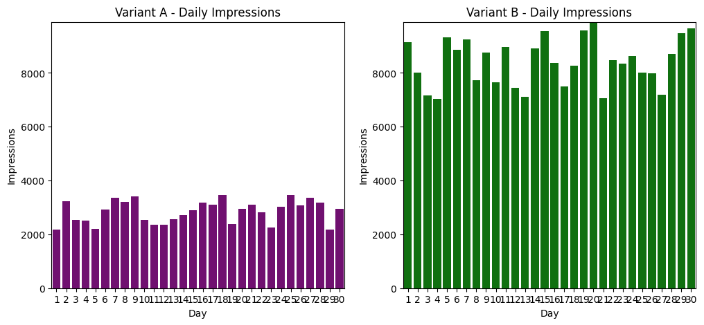

```python
max_val = max(A_data['Impressions'].max(), B_data['Impressions'].max())

plt.figure(figsize=(12,5))

# Variant A - Bar chart
plt.subplot(1,2,1)
sns.barplot(x=A_data['Day'], y=A_data['Impressions'], color='purple')
plt.title('Variant A - Daily Impressions')
plt.xlabel('Day')
plt.ylabel('Impressions')
plt.ylim(0, max_val)

# Variant B - Bar chart
plt.subplot(1,2,2)
sns.barplot(x=B_data['Day'], y=B_data['Impressions'], color='green')
plt.title('Variant B - Daily Impressions')
plt.xlabel('Day')
plt.ylabel('Impressions')
plt.ylim(0, max_val)

plt.show()
```

## Impressions — Key Insights

### Impressions

- Variant A averages around `2,000 – 4,000` impressions per day
- Variant B averages around `8,000 – 10,000` impressions per day

### Key Insights

- Variant B gets nearly `3x` more impressions than Variant A every single day — this is a huge and consistent gap
- There is not a single day where Variant A matched or beat Variant B, which strongly suggests the difference is **real and not random**
- Variant B stays high throughout all 30 days — the redesigned thumbnail continuously attracted more viewers

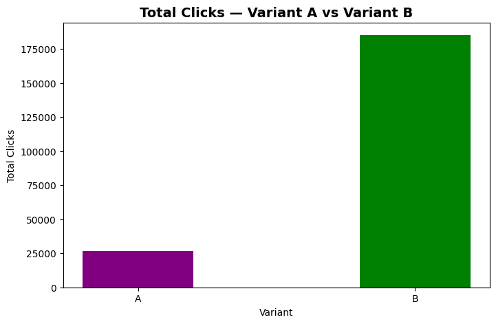

```python
plt.figure(figsize=(8, 5))

total_clicks = df.groupby('Variant')['Clicks'].sum()

plt.bar(total_clicks.index, total_clicks.values, color=['purple', 'green'], width=0.4)

plt.title('Total Clicks — Variant A vs Variant B', fontsize=14, fontweight='bold')
plt.xlabel('Variant')
plt.ylabel('Total Clicks')
plt.show()
```

## Clicks — Key Insights

### Clicks

- Variant A total clicks: `~26,000`
- Variant B total clicks: `~185,000`

### Key Insights

- Variant B has `7x` more total clicks than Variant A — an enormous difference over 30 days
- The original thumbnail failed to attract clicks consistently throughout the experiment
- The redesigned thumbnail drove significantly more traffic

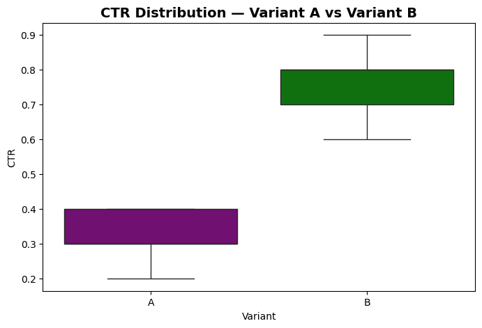

```python
plt.figure(figsize=(8, 5))

sns.boxplot(data=df, x='Variant', y='CTR', palette=['purple', 'green'])

plt.title('CTR Distribution — Variant A vs Variant B', fontsize=14, fontweight='bold')
plt.xlabel('Variant')
plt.ylabel('CTR')
plt.show()
```

## CTR Distribution — Key Insights

### CTR

- Variant A CTR ranges from `0.2 to 0.4`
- Variant B CTR ranges from `0.6 to 0.9`

### Key Insights

- Variant A median is around `0.3` — means half the days performed below 30% CTR and Variant B median is around `0.75` — means half the days performed above 75% CTR
- Variant B has a wider spread — even if its CTR varied more day to day but always stayed high

## ⚖️ Hypothesis Testing

```python
clicks = [
    A_data['Clicks'].sum(),
    B_data['Clicks'].sum()
]

impressions = [
    A_data['Impressions'].sum(),
    B_data['Impressions'].sum()
]

print("Clicks:", clicks)
print("Impressions:", impressions)
```

```
Clicks: [np.int64(26533), np.int64(185241)]
Impressions: [np.int64(85466), np.int64(251955)]
```

```python
stat, pval = proportions_ztest(count=clicks, nobs=impressions, alternative='two-sided')
```

```python
print("----- Z-test for CTR -----")
print("Z-test statistic:", stat)
print("p-value:", pval)
print("\n")

if pval < 0.05:
    print("✅ Reject H0: Variant B has significantly higher CTR than Variant A")
else:
    print("❌ Fail to reject H0: No significant difference in CTR")
```

```
----- Z-test for CTR -----
Z-test statistic: -221.96230653986697
p-value: 0.0


✅ Reject H0: Variant B has significantly higher CTR than Variant A
```

## 📝 Conclusion

Based on the 30-day A/B test conducted on two YouTube thumbnail designs, **Variant B significantly outperforms Variant A** across all key metrics.

### Hypothesis Testing Findings

- Z-Test: CTR difference is statistically significant `(p < 0.05)`
- We reject H0 — the difference is real and not due to random chance

### ✅ Recommendation

Switch to **Variant B** The YouTuber should immediately switch to Variant B as the default thumbnail. The redesigned thumbnail with bold visuals and the creator's face visible is far more effective at attracting viewer attention, driving clicks, and keeping viewers engaged longer.

[figure not shown]